# Circular GLMM Summary: Dance States

James Foster

2026-10-20

# Details

**DESCRIPTION**

Load and plot the state-switching circular GLMM fitted in `HS_circGLMM_states.ipynb`, which assigns each dance to a forward, reversed or axial (bimodal) state and models the probability of each state as a function of condition. The analysis to summarise is set by `params`: the solar elevation (low), the direction prior (bounded) and the model (three_states_condition), read from `params$model_dir`.

**INPUTS**

`HS_functions.R`, `0Data/hs_dance_states_<elevation>.feather`, `2Results/state_models/HS_states_<elevation>_<direction_prior>_*.nc`

**OUTPUTS**

Plotted estimates, predictions and contrasts.

**REFERENCES**

**modelling methods**

- Graving JM, Sayin S, Costelloe BR, Goldshtein A & Foster JJ. Unwrapping circular statistics with Bayesian multilevel models.
- Abril-Pla, O., Andreani, V., Carroll, C., Dong, L., Fonnesbeck, C. J., Kochurov, M., Kumar, R., Lao, J., Luhmann, C. C., Martin, O. A., et al. (2023). `PyMC`: a modern, and comprehensive probabilistic programming framework in Python. *PeerJ Computer Science* 9, e1516.
- Seyboldt, A., Carlson, E. L., & Carpenter, B. (2026). Preconditioning Hamiltonian Monte Carlo by minimizing Fisher Divergence. *arXiv* preprint arXiv:2603.18845.
- Yao, Y., Vehtari, A., & Gelman, A. (2022). Stacking for non-mixing Bayesian computations: the curse and blessing of multimodal posteriors. *Journal of Machine Learning Research* 23(79), 1-45.

# Motivation

On a horizontal comb, and under some skylight conditions, honeybee dances are not always oriented in a single direction relative to the feeder: some dances point away from the feeder (reversed), and others alternate between two opposite directions (axial). Rather than describing these by a continuous mixture weight, each dance is assigned to one of three latent states:

| state | density of each waggle run |
| --- | --- |
| forward | $\mathcal{M}(\theta \mid \mu_d, \kappa_d)$ |
| reversed | $\mathcal{M}(\theta \mid \mu_d + \pi, \kappa_d)$ |
| axial | $w\,\mathcal{M}(\theta \mid \mu_d, \kappa_d) + (1-w)\,\mathcal{M}(\theta \mid \mu_d + \pi, \kappa_d)$, $0.25 < w < 0.75$ |

The probability of each state is modelled with a multinomial logit (forward as reference), with condition effects and individual random effects:

$\log(\pi_\text{reversed} / \pi_\text{forward}) \sim$ condition + (1 |Individual)

$\log(\pi_\text{axial} / \pi_\text{forward}) \sim$ condition + (1 |Individual)

The forward direction of each dance, $\mu_d$, combines a direction for its condition with individual and dance offsets, and the concentration, $\kappa_d$, has condition effects and individual and dance random effects. Condition effects are coded as successive differences, vertical → horizontal → antisolar → solar (H, A, S), as in `HS_circGLMM_fit_4cond.ipynb`. To keep reversals from being described by 180° changes in direction, condition directions and dance offsets are bounded (see `HS_circGLMM_states.ipynb`), and individual offsets have a strongly concentrated von Mises prior ($\kappa_u \sim \text{LogNormal}(\log 30, 0.6)$). Chains that settled in poor local optima (mean log posterior more than 20 below the best chain) were dropped before saving.

# Set up workspace

To extract these models, we need to load the appropriate functions. Make sure that the `circular`, `reticulate`, `arrow`, `posterior` and `bayesplot` packages are installed. Here we use the `HS-env` conda environment created for `HS_circGLMM_fit_4cond.ipynb`, so that `arviz` can read the saved model. If it does not exist yet, create it from a terminal with conda available (e.g. Anaconda Prompt):

`conda create -n HS-env python=3.12 -c conda-forge -y`

`conda activate HS-env`

`pip install -r nutpie_unwrap_requirements.txt`

`reticulate` cannot always find the conda binary (e.g. RStudio on Windows with an “All Users” install in `C:/ProgramData`), so we search the usual install locations. To use a different conda binary or environment, set `RETICULATE_CONDA` or `HS_CONDA_ENV` in your `~/.Renviron`.

```r
source('HS_functions.R')
require(reticulate) #run python from R
#conda environment in which the model was fitted
hs_env = Sys.getenv('HS_CONDA_ENV', unset = 'HS-env')
#find the conda binary, unless the user has specified one
if(!nzchar(Sys.getenv('RETICULATE_CONDA')))
{
  conda_roots = c(Sys.getenv(c('USERPROFILE', 'LOCALAPPDATA', 'ProgramData', 'HOME')),
                  '/opt', '/usr/local')
  conda_dists = c('anaconda3', 'miniconda3', 'miniforge3', 'mambaforge')
  conda_bins = if(.Platform$OS.type == 'windows'){'Scripts/conda.exe'}else{'bin/conda'}
  conda_candidates = c(Sys.getenv('CONDA_EXE'), #set inside an activated conda shell
                       Sys.which('conda'), #on the PATH
                       file.path(rep(conda_roots[nzchar(conda_roots)],
                                     each = length(conda_dists)),
                                 conda_dists,
                                 conda_bins)
                       )
  conda_found = Filter(function(x){nzchar(x) & file.exists(x)},
                       conda_candidates)
  if(length(conda_found))
  {
    Sys.setenv(RETICULATE_CONDA = normalizePath(conda_found[1], winslash = '/'))
  }
}
#use the environment, with instructions if it cannot be found
tryCatch(use_condaenv(hs_env, required = TRUE),
         error = function(e)
         {
           stop('Could not use conda environment "', hs_env, '": ', conditionMessage(e),
                '\nCreate it (see above), or set RETICULATE_CONDA to the path of your conda binary.',
                call. = FALSE)
         }
         )
reticulate::py_config()
```

```
## python:         C:/Users/James Foster/.conda/envs/HS-env/python.exe
## libpython:      C:/Users/James Foster/.conda/envs/HS-env/python312.dll
## pythonhome:     C:/Users/James Foster/.conda/envs/HS-env
## version:        3.12.15 | packaged by conda-forge | (main, Oct 13 2026, 16:44:09) [MSC v.1944 64 bit (AMD64)]
## Architecture:   64bit
## numpy:          C:/Users/James Foster/.conda/envs/HS-env/Lib/site-packages/numpy
## numpy_version:  1.26.4
##
## NOTE: Python version was forced by use_python() function
```

```r
#load .feather files (readable in R and Python)
require(arrow)
```

```r
#process and plot MCMC data
require(posterior)
require(bayesplot)
options(posterior.num_args = list(sigfig = 3))#for ease of reading

#condition colours, as in HS_ExploratoryPlots.Rmd
cond_cols = list(
  vertical = 'darkred',
  horizontal = 'darkgreen',
  antisolar = 'cyan4',
  solar = 'blue4'
)
#state colours
state_cols = list(
  forward = '#1b7837',
  reversed = '#762a83',
  axial = '#e08214'
)
states = names(state_cols)
#successive model effects for each condition
cond_effs_all = list(vertical = character(0),
                     horizontal = c('H'),
                     antisolar = c('H', 'A'),
                     solar = c('H', 'A', 'S'))
```

# Prepare data

Load the data in the exact form used to fit the model, saved by `HS_circGLMM_states.ipynb` as a `.feather` file (readable in both `R` and `Python`). Dances and individuals are numbered from 0 in the order of their labels, matching the model’s coordinates.

```r
hd = read_feather(file = file.path('0Data',
                                   paste0('hs_dance_states_', params$elevation, '.feather')))
hd = as.data.frame(hd)
hd = within(hd,
            {
              condition = droplevels(factor(as.character(condition),
                                            levels = names(cond_cols)))
              angle_deg = deg(angle) # in degrees, for plotting
            }
)
conds = levels(hd$condition)
cond_effs = cond_effs_all[conds]
effect_names = unique(unlist(cond_effs))
#one row per dance (0-based codes, as in the model)
dance_tab = unique(hd[, c('Dance', 'Dance_label', 'Individual', 'Individual_label', 'condition')])
dance_tab = dance_tab[order(dance_tab$Dance), ]
id_tab = unique(hd[, c('Individual', 'Individual_label')])
id_tab = id_tab[order(id_tab$Individual), ]
n_dance = nrow(dance_tab)
n_ind = nrow(id_tab)
#which individuals danced in which conditions (rows ordered by Individual)
id_cond = sapply(conds,
                 function(cnd)
                 {
                   id_tab$Individual %in% subset(hd, condition %in% cnd)$Individual
                 }
                 )
print(paste('Elevation:', params$elevation, '; conditions:', paste(conds, collapse = ', ')))
```

```
## [1] "Elevation: low ; conditions: vertical, horizontal"
```

```r
#runs, dances and individuals per condition
aggregate(cbind(runs = angle) ~ condition, data = hd, FUN = length)
```

```
##    condition runs
## 1   vertical  382
## 2 horizontal  556
```

```r
with(unique(hd[, c('Individual_label', 'Dance_label', 'condition')]),
     table(Individual_label, condition))
```

```
##                 condition
## Individual_label vertical horizontal
##              11r        1          0
##              17y        2          2
##              20y        3          9
##              22b        4          6
##              23y        2          3
##              25y        0          1
##              47y        6          4
##              60r        1          1
##              62b        0          2
##              66b        2          0
##              73b        1          7
##              81r        2          5
##              82b        0          1
##              84b        5          6
##              84r        1          1
##              88b        0          1
##              90r        1          8
##              92w        0          1
##              95r        2          7
##              9b         1          0
```

# Load model and extract draws

This loads draws from the fitted model’s posterior distribution, using the `reticulate` package to read the `Python` `arviz` file. Each parameter is extracted as an array of samples $\times$ levels (with draws running sequentially within each chain), and population-level parameters are collected into a `draws_df` for trace plots.

```r
az = reticulate::import("arviz")
model_file = file.path(params$model_dir,
                       paste0('HS_states_', params$elevation, '_', params$direction_prior, '_',
                              params$model, '.nc'))
print(model_file)
```

```
## [1] "2Results/state_models/HS_states_low_bounded_three_states_condition.nc"
```

```r
idata = az$from_netcdf(model_file)
post = idata$posterior
post_vars = unlist(reticulate::iterate(post$data_vars$keys()))
n_chains = as.integer(post$sizes['chain'])
n_draws = as.integer(post$sizes['draw'])
n_samp = n_chains * n_draws

#Extract a parameter as samples (x levels (x levels)), draws within chains
Draws = function(name)
{
  vals = reticulate::py_get_item(post, name)$values
  d = dim(vals)
  if(length(d) == 2)
  {
    as.vector(t(vals))
  }else if(length(d) == 3)
  {
    matrix(aperm(vals, c(2, 1, 3)), ncol = d[3])
  }else
  {
    array(aperm(vals, c(2, 1, 3, 4)), dim = c(n_samp, d[3], d[4]))
  }
}
#Coordinates of a dimension
Coords = function(dim_name)
{
  as.character(reticulate::py_get_item(post$coords, dim_name)$values)
}
model_states = Coords('state')
stopifnot(all(Coords('dance') == dance_tab$Dance_label),
          all(Coords('condition') == conds))

#population-level parameters
mu_cond = Draws('mu_condition') # samples x conditions
colnames(mu_cond) = conds
kappa0 = Draws('kappa_Intercept')
kappa_eff = if(length(effect_names)){Draws('kappa_effect')}else{NULL}
state_int = lapply(setNames(model_states[-1], model_states[-1]),
                   function(s){Draws(paste0(s, '_Intercept'))})
state_eff = lapply(setNames(model_states[-1], model_states[-1]),
                   function(s)
                   {
                     nm = paste0(s, '_effect')
                     if(nm %in% post_vars){m = Draws(nm); colnames(m) = effect_names; m}else{NULL}
                   })
w_axial = if('w_axial' %in% post_vars){Draws('w_axial')}else{rep(0.5, n_samp)}
#group-level parameters
mu_dance = Draws('mu') # samples x dances: forward direction of each dance
kappa_dance = Draws('kappa') # samples x dances
p_state = Draws('p_state') # samples x dances x states: posterior state probabilities
ind_state_z = lapply(setNames(model_states[-1], model_states[-1]),
                     function(s)
                     {
                       sweep(Draws(paste0(s, '_Individual_z')), 1,
                             Draws(paste0(s, '_Individual_sigma')), '*')
                     })
#individual direction offsets: von Mises or non-centred Normal, depending on the direction prior
mu_ind = if('mu_Individual' %in% post_vars)
{
  Draws('mu_Individual')
}else
{
  sweep(Draws('mu_Individual_z'), 1, Draws('mu_Individual_sigma'), '*')
}
bounded_dirs = grepl('bounded', params$direction_prior)

#trace-plot data frame of population-level parameters
draws_list = list(.chain = rep(1:n_chains, each = n_draws),
                  .iteration = rep(1:n_draws, times = n_chains))
for(cnd in conds){draws_list[[paste0('mu_', cnd)]] = mu_cond[, cnd]}
draws_list$kappa_Intercept = kappa0
for(e in effect_names){draws_list[[paste0('kappa_', e)]] = kappa_eff[, which(effect_names == e)]}
for(s in names(state_int))
{
  draws_list[[paste0(s, '_Intercept')]] = state_int[[s]]
  for(e in effect_names){if(!is.null(state_eff[[s]])){draws_list[[paste0(s, '_', e)]] = state_eff[[s]][, e]}}
}
draws_list$w_axial = w_axial
for(nm in c('mu_Individual_sigma', 'mu_Dance_sigma', 'kappa_Individual_sigma', 'kappa_Dance_sigma',
            'reversed_Individual_sigma', 'axial_Individual_sigma'))
{
  if(nm %in% post_vars){draws_list[[nm]] = Draws(nm)}
}
draws_final = posterior::as_draws_df(as.data.frame(draws_list, check.names = FALSE))
```

# Inspect model estimates

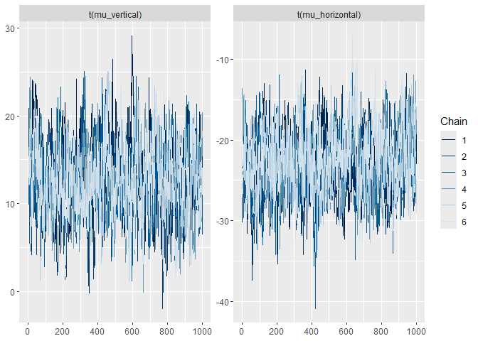

```r
mcmc_trace(draws_final,
           pars = paste0('mu_', conds),
           transformations = unwrap_circular_deg)
```

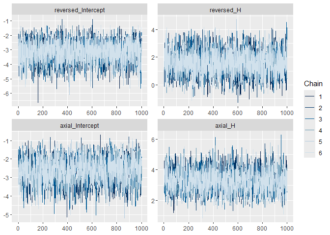

```r
mcmc_trace(draws_final,
           pars = grep('^(reversed|axial)_(Intercept|[HAS])$', names(draws_final), value = TRUE))
```

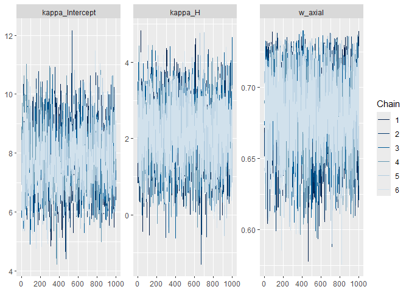

```r
mcmc_trace(draws_final,
           pars = c(grep('^kappa_(Intercept|[HAS])$', names(draws_final), value = TRUE), 'w_axial'))
```

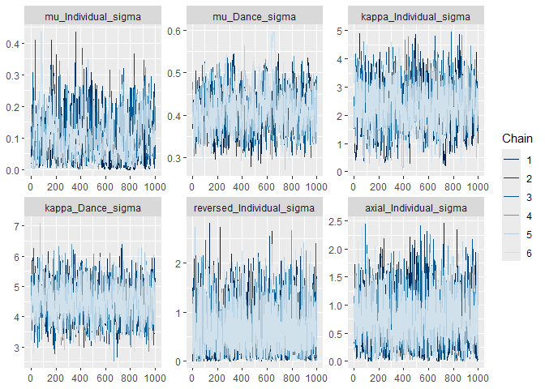

```r
mcmc_trace(draws_final,
           pars = grep('_sigma$', names(draws_final), value = TRUE))
```

Check the $\hat{R}$ values (convergence is indicated by $\hat{R}<1.01$) and the number of chains kept after screening.

```r
print(paste('Chains kept after screening:', n_chains,
            '; divergent transitions:',
            sum(reticulate::py_get_item(idata$sample_stats, 'diverging')$values)))
```

```
## [1] "Chains kept after screening: 6 ; divergent transitions: 0"
```

```r
main_vars = intersect(c('mu_condition', 'kappa_Intercept', 'kappa_effect',
                        'reversed_Intercept', 'reversed_effect', 'axial_Intercept', 'axial_effect',
                        'w_axial', 'mu_Individual_sigma', 'mu_Dance_sigma',
                        'kappa_Individual_sigma', 'kappa_Dance_sigma',
                        'reversed_Individual_sigma', 'axial_Individual_sigma'),
                      post_vars)
azsum = az$summary(idata, var_names = as.list(main_vars), circ_var_names = list('mu_condition'))
print(azsum[, c(1, 3, 4, 7, 9)], digits = 3)
```

```
##                             mean hdi_3% hdi_97% ess_bulk r_hat
## mu_condition[vertical]     0.223  0.088   0.354      419  1.01
## mu_condition[horizontal]  -0.399 -0.517  -0.269      435  1.02
## kappa_Intercept            7.869  5.998   9.718     1107  1.01
## kappa_effect[H]            2.115  0.568   3.541     2058  1.00
## reversed_Intercept        -3.152 -4.549  -1.924     3267  1.00
## reversed_effect[H]         1.626  0.108   3.179     3311  1.00
## axial_Intercept           -2.626 -3.928  -1.472     2008  1.00
## axial_effect[H]            3.312  2.060   4.626     1963  1.00
## w_axial                    0.683  0.636   0.731     2234  1.00
## mu_Individual_sigma        0.096  0.000   0.216      160  1.05
## mu_Dance_sigma             0.411  0.325   0.489      614  1.01
## kappa_Individual_sigma     2.283  0.889   3.743      762  1.01
## kappa_Dance_sigma          4.484  3.459   5.518     1352  1.00
## reversed_Individual_sigma  0.596  0.000   1.403     1771  1.00
## axial_Individual_sigma     0.736  0.001   1.431     1204  1.00
```

# Extract predictions

The posterior is summarised by its median and central $95\%$ interval. For circular quantities, draws are centred on their circular median before calculating quantiles, so that the boundary falls far from the bulk of the estimates.

```r
#A function to find the circular median in (-pi, pi)
MedCDraws = function(x,
                     templ = 'none', #assumes radians
                     medn = 1) #take the 1st median
{
  median.circular( circular(x = mod_circular(x),
                            template = templ)
                                           )[medn]
}
#A function to report circular quantiles in degrees, centred on the circular median
QDegDraws = function(x,
                     probs = c(0.5, 0.025, 0.975))
{
  mx = as.numeric(MedCDraws(x))
  round(deg(
    quantile(mod_circular(x - mx), probs = probs) + mx
  ))
}
#A function to report linear quantiles
QDraws = function(x,
                  probs = c(0.5, 0.025, 0.975),
                  digits = 2)
{
  round(quantile(x, probs = probs),
        digits = digits)
}
#Bounded offset, as in the model (B*tanh(x/B))
Bounded = function(x, bound = pi/3)
{
  bound * tanh(x / bound)
}
#Condition design: which successive effects apply to each condition
XCond = function(cnd){as.numeric(effect_names %in% cond_effs[[cnd]])}
#Population concentration for a condition
KappaCond = function(cnd)
{
  eta = kappa0
  if(length(effect_names)){eta = eta + kappa_eff %*% XCond(cnd)}
  softplus(as.vector(eta))
}
#State probabilities for a condition, optionally for an individual: samples x states
StateProbs = function(cnd, i = NULL)
{
  eta = sapply(model_states,
               function(s)
               {
                 if(s == 'forward'){return(rep(0, n_samp))}
                 e = state_int[[s]]
                 if(!is.null(state_eff[[s]])){e = e + as.vector(state_eff[[s]] %*% XCond(cnd))}
                 if(!is.null(i)){e = e + ind_state_z[[s]][, i + 1]}
                 e
               })
  exp(eta - apply(eta, 1, max)) / rowSums(exp(eta - apply(eta, 1, max)))
}
#Expected weight of the forward direction (mu1) in a dance, given its state probabilities:
#forward dances put all runs at mu1, axial dances a proportion w, reversed dances none
WForward = function(ps)
{
  ps[, 'forward'] + if('axial' %in% colnames(ps)){w_axial * ps[, 'axial']}else{0}
}
```

## Population-level predictions for each condition

For a typical individual (individual effects at zero): the forward direction ($\mu_1$, with the reverse direction $\mu_2 = \mu_1 + 180°$), concentration ($\kappa$, and mean vector length $\rho = A_1(\kappa)$), the probability of each state, and the expected proportion of waggle runs towards $\mu_1$, $w_1 = \pi_\text{forward} + w\,\pi_\text{axial}$.

```r
pop_draws = lapply(setNames(conds, conds),
                   function(cnd)
                   {
                     ps = StateProbs(cnd)
                     colnames(ps) = model_states
                     list(mu = mu_cond[, cnd],
                          kappa = KappaCond(cnd),
                          p = ps,
                          w1 = WForward(ps))
                   })

pred_table = do.call(rbind,
                     lapply(conds,
                            function(cnd)
                            {
                              pd = pop_draws[[cnd]]
                              mq = QDegDraws(pd$mu)
                              kq = QDraws(pd$kappa)
                              rq = QDraws(A1(pd$kappa), digits = 3)
                              data.frame(condition = cnd,
                                         mu_median = mq[1], mu_lower = mq[2], mu_upper = mq[3],
                                         kappa_median = kq[1], kappa_lower = kq[2], kappa_upper = kq[3],
                                         rho_median = rq[1], rho_lower = rq[2], rho_upper = rq[3],
                                         row.names = NULL)
                            }
                     )
)
print(pred_table)
```

```
##    condition mu_median mu_lower mu_upper kappa_median kappa_lower kappa_upper
## 1   vertical        13        5       21         7.86        5.94        9.85
## 2 horizontal       -23      -30      -15         9.96        8.17       11.99
##   rho_median rho_lower rho_upper
## 1      0.934     0.911     0.948
## 2      0.948     0.937     0.957
```

```r
state_table = do.call(rbind,
                      lapply(conds,
                             function(cnd)
                             {
                               do.call(rbind,
                                       lapply(c(model_states, 'w1'),
                                              function(s)
                                              {
                                                x = if(s == 'w1'){pop_draws[[cnd]]$w1}else{pop_draws[[cnd]]$p[, s]}
                                                q = QDraws(x, digits = 3)
                                                data.frame(condition = cnd, quantity = s,
                                                           median = q[1], lower = q[2], upper = q[3],
                                                           row.names = NULL)
                                              }))
                             }))
print(state_table)
```

```
##    condition quantity median lower upper
## 1   vertical  forward  0.887 0.754 0.956
## 2   vertical reversed  0.039 0.009 0.124
## 3   vertical    axial  0.066 0.017 0.185
## 4   vertical       w1  0.936 0.852 0.976
## 5 horizontal  forward  0.311 0.167 0.481
## 6 horizontal reversed  0.071 0.018 0.178
## 7 horizontal    axial  0.613 0.424 0.784
## 8 horizontal       w1  0.732 0.646 0.801
```

```r
print(paste('Axial weight w (proportion of runs towards mu1 in axial dances):',
            paste(QDraws(w_axial, digits = 3), collapse = ', ')))
```

```
## [1] "Axial weight w (proportion of runs towards mu1 in axial dances): 0.685, 0.626, 0.728"
```

## State probabilities by condition

Bars show the population-level probability of each state in each condition (median and $95\%$ interval, typical individual); points show the mean posterior state probability across the observed dances in that condition.

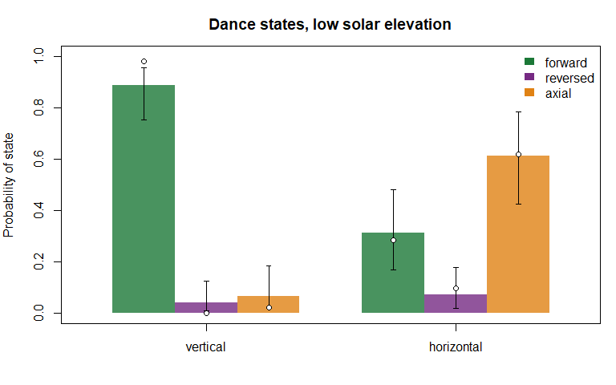

```r
#mean posterior state probability across observed dances
p_state_mean = apply(p_state, c(2, 3), mean) # dances x states
colnames(p_state_mean) = model_states
par(mar = c(4, 4, 3, 1))
plot(NULL, xlim = c(0.5, length(conds) + 0.5), ylim = c(0, 1), xaxt = 'n',
     xlab = '', ylab = 'Probability of state',
     main = paste('Dance states,', params$elevation, 'solar elevation'))
axis(1, at = seq_along(conds), labels = conds)
width = 0.25
for(j in seq_along(model_states))
{
  s = model_states[j]
  xs = seq_along(conds) + (j - (length(model_states) + 1) / 2) * width
  q = sapply(conds, function(cnd){quantile(pop_draws[[cnd]]$p[, s], c(0.5, 0.025, 0.975))})
  rect(xs - width / 2, 0, xs + width / 2, q[1, ], col = adjustcolor(state_cols[[s]], alpha.f = 0.8), border = NA)
  arrows(xs, q[2, ], xs, q[3, ], angle = 90, code = 3, length = 0.03)
  obs = sapply(conds, function(cnd){mean(p_state_mean[dance_tab$condition == cnd, s])})
  points(xs, obs, pch = 21, bg = 'white')
}
legend('topright', legend = model_states, fill = unlist(state_cols[model_states]), border = NA, bty = 'n')
```

## Effects of condition on states, direction and concentration

Contrasts between successive conditions (the model effects H, A, S) and between each condition and vertical, for a typical individual. $P(>0)$ is the posterior probability that the quantity increases.

```r
contrasts = c(lapply(conds[-1], function(cnd){c(cnd, 'vertical')}),
              if(length(conds) > 2){lapply(3:length(conds), function(k){c(conds[k], conds[k - 1])})})
names(contrasts) = sapply(contrasts, paste, collapse = ' - ')
contrast_table = do.call(rbind,
                         lapply(names(contrasts),
                                function(cname)
                                {
                                  cn = contrasts[[cname]]
                                  p1 = pop_draws[[cn[1]]]; p0 = pop_draws[[cn[2]]]
                                  rows = lapply(c(model_states, 'w1', 'kappa', 'mu (°)'),
                                                function(q)
                                                {
                                                  d = switch(q,
                                                             w1 = p1$w1 - p0$w1,
                                                             kappa = p1$kappa - p0$kappa,
                                                             `mu (°)` = mod_circular(p1$mu - p0$mu),
                                                             p1$p[, q] - p0$p[, q])
                                                  qq = if(q == 'mu (°)'){QDegDraws(d)}else{QDraws(d, digits = 3)}
                                                  data.frame(contrast = cname, quantity = q,
                                                             median = qq[1], lower = qq[2], upper = qq[3],
                                                             P_greater_0 = round(mean(d > 0), 3),
                                                             row.names = NULL)
                                                })
                                  do.call(rbind, rows)
                                }))
print(contrast_table)
```

```
##                contrast quantity  median   lower   upper P_greater_0
## 1 horizontal - vertical  forward  -0.569  -0.722  -0.388       0.000
## 2 horizontal - vertical reversed   0.028  -0.056   0.132       0.767
## 3 horizontal - vertical    axial   0.538   0.345   0.709       1.000
## 4 horizontal - vertical       w1  -0.201  -0.287  -0.109       0.000
## 5 horizontal - vertical    kappa   2.131   0.548   3.645       0.996
## 6 horizontal - vertical   mu (°) -36.000 -46.000 -26.000       0.000
```

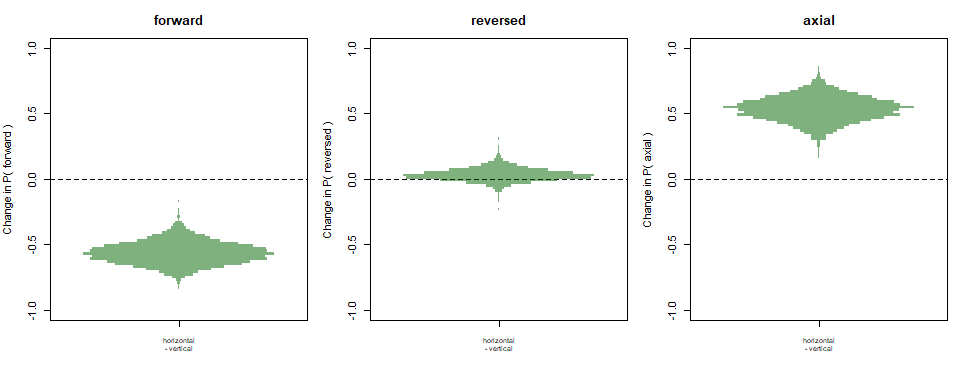

```r
par(mfrow = c(1, length(model_states)), mar = c(5, 4, 3, 1))
for(s in model_states)
{
  dl = lapply(contrasts, function(cn){pop_draws[[cn[1]]]$p[, s] - pop_draws[[cn[2]]]$p[, s]})
  plot(NULL, xlim = c(0.5, length(dl) + 0.5), ylim = c(-1, 1), xaxt = 'n',
       xlab = '', ylab = paste('Change in P(', s, ')'), main = s)
  axis(1, at = seq_along(dl), labels = gsub(' - ', '\n- ', names(dl)), cex.axis = 0.7, padj = 0.5)
  abline(h = 0, lty = 2)
  for(k in seq_along(dl))
  {
    hst = hist(dl[[k]], breaks = seq(-1, 1, by = 0.02), plot = FALSE)
    dens = 0.4 * hst$density / max(hst$density)
    rect(k - dens, head(hst$breaks, -1), k + dens, hst$breaks[-1],
         col = adjustcolor(cond_cols[[contrasts[[k]][1]]], alpha.f = 0.5), border = NA)
  }
}
```

## Extracting individual- and dance-specific predictions

**Individuals**: for each individual in each condition in which it danced, the forward direction ($\mu_c$ plus the individual’s offset) and state probabilities (including the individual’s random effects on the state logits), from which the expected proportion of runs towards $\mu_1$ ($w_1$) is calculated.

**Dances**: each dance’s forward direction and concentration from the model, and its *posterior* state probabilities given its own waggle runs.

```r
mu_id = kappa_id = w1_id = matrix(NA, nrow = n_ind, ncol = length(conds), dimnames = list(NULL, conds))
individual_draws = vector('list', n_ind)
for(i in id_tab$Individual)
{
  individual_draws[[i + 1]] = list(mu = list(), kappa = list(), w1 = list())
  for(cnd in conds[id_cond[id_tab$Individual == i, ]])
  {
    off = mu_ind[, i + 1]
    mu_i = mu_cond[, cnd] + if(bounded_dirs){Bounded(off)}else{off}
    ps = StateProbs(cnd, i = i)
    colnames(ps) = model_states
    w1 = WForward(ps)
    kp = KappaCond(cnd)
    individual_draws[[i + 1]]$mu[[cnd]] = mu_i
    individual_draws[[i + 1]]$kappa[[cnd]] = kp
    individual_draws[[i + 1]]$w1[[cnd]] = w1
    mu_id[i + 1, cnd] = MedCDraws(mu_i)
    kappa_id[i + 1, cnd] = median(kp)
    w1_id[i + 1, cnd] = median(w1)
  }
}

#dances: forward direction, concentration and posterior expected weight towards mu1
mu_dance_med = apply(mu_dance, 2, function(x){as.numeric(MedCDraws(x))})
kappa_dance_med = apply(kappa_dance, 2, median)
ps_d = p_state_mean
w1_dance = ps_d[, 'forward'] + if('axial' %in% model_states){median(w_axial) * ps_d[, 'axial']}else{0}
dance_tab = within(dance_tab,
                   {
                     state_map = model_states[apply(ps_d, 1, which.max)]
                     state_prob = apply(ps_d, 1, max)
                   })
print(table(dance_tab$condition, dance_tab$state_map))
```

```
##
##              axial forward reversed
##   vertical       0      34        0
##   horizontal    42      18        5
```

```r
print(paste('Dances assigned with probability < 0.8:', sum(dance_tab$state_prob < 0.8), 'of', n_dance))
```

```
## [1] "Dances assigned with probability < 0.8: 15 of 99"
```

### Visualising individual predictions

For each bee in each condition: the observed waggle runs, density contours for the population-level mean vector of each mode in that condition (forward mode in red-yellow, reverse mode in blue, opacity scaled by its weight), thin lines for each dance’s two modes, and arrows for the individual’s two modes. Each mode is drawn with length $A_1(\kappa)$ and line width scaled by its weight ($w_1$ and $1 - w_1$), following `PlotMV_circMLE`, with a minimum width of 0.5 so that minor modes remain visible; opacity is also scaled by weight (minimum 25%), so that many overlapping minor modes do not look like a major one.

```r
#Plot separate mean vectors for each mode (mu1 and mu1 + pi), each of length A1(kappa),
#with line width scaled by the weight of that mode (as in PlotMV_circMLE: lwd = 5 * weight1)
ModeArrows = function(mu, kappa, w1, col, lwd = 5, lwd_min = 0.5, length = 0, alpha = 200/255)
{
  mus = c(mu, mod_circular(mu + pi))
  ws = c(w1, 1 - w1)
  for(md in 1:2)
  {
    arrows.circular(
      x = circular(mus[md], units = 'radians', rotation = 'clock', zero = pi/2),
      y = A1(kappa),
      lwd = max(lwd_min, lwd * ws[md]),
      length = length,
      #fade minor modes too, so that overlapping thin lines do not look like a major mode
      col = adjustcolor(col, alpha.f = alpha * max(0.25, ws[md]))
    )
  }
}
#Posterior density contours for the mean vector of each mode, opacity scaled by its weight
ModeContours = function(mu, kappa, w1)
{
  dl = list(mu = mu, kappa = kappa)
  w_med = median(w1)
  Draws2Cont(dl, alpha = 200/255 * w_med,
             x_string = 'sin(mu) * A1(kappa)', y_string = 'cos(mu) * A1(kappa)')
  Draws2Cont(dl, palette = 'Blues 3', alpha = 200/255 * (1 - w_med),
             x_string = '-sin(mu) * A1(kappa)', y_string = '-cos(mu) * A1(kappa)')
}
```

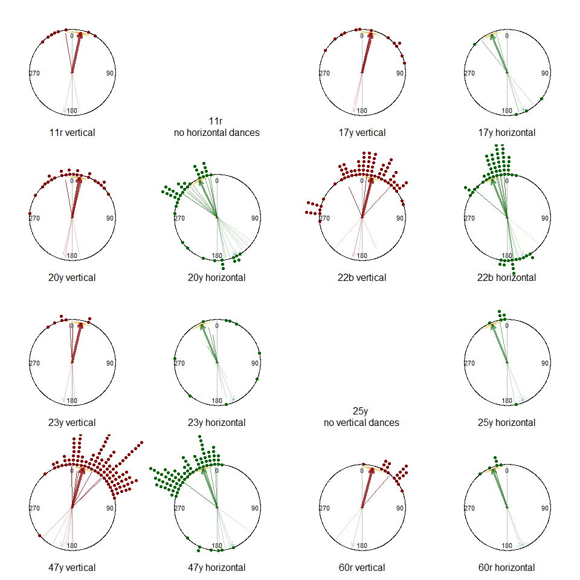

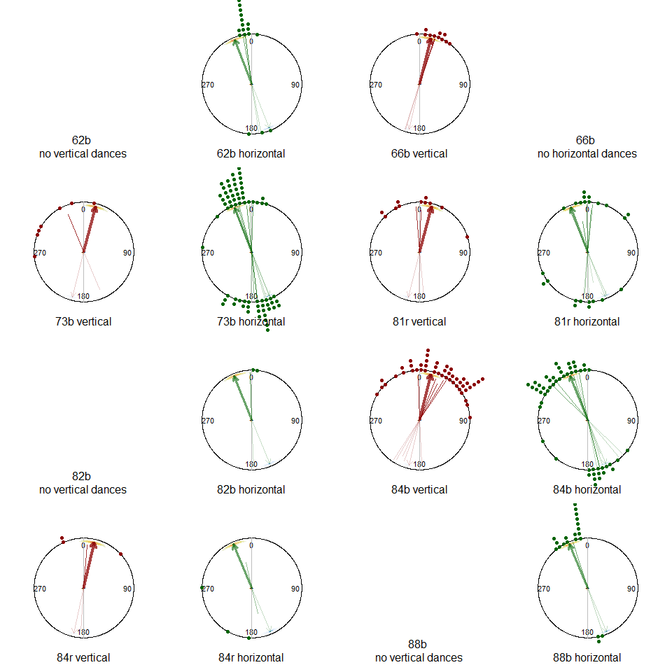

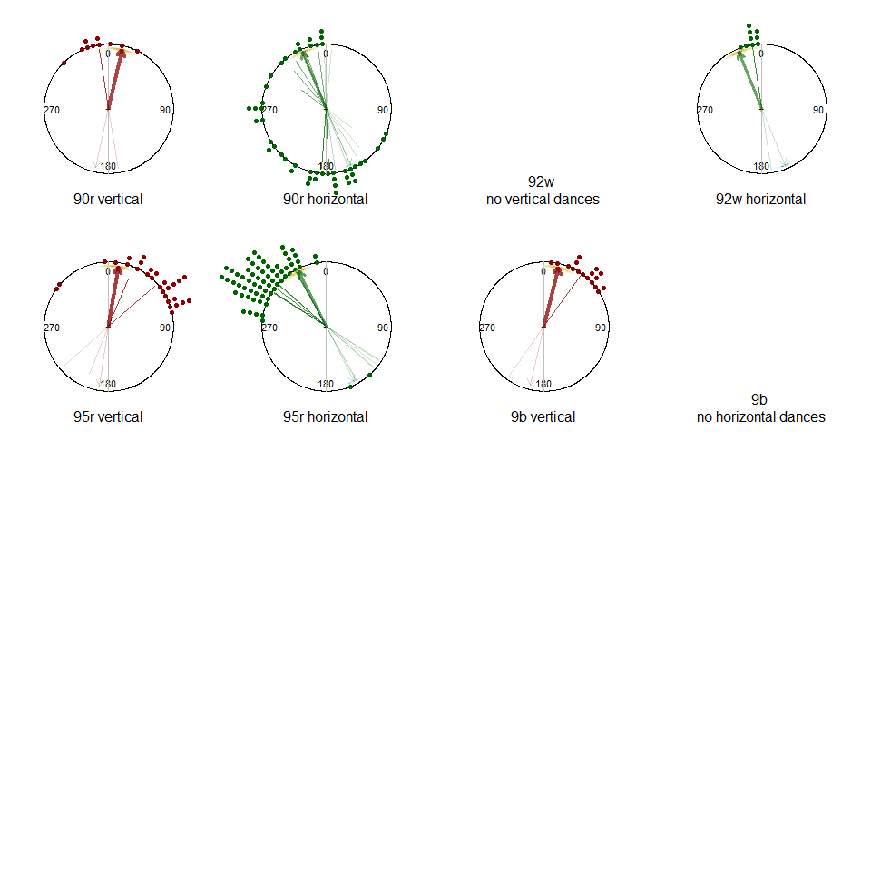

```r
par(pty = 's')
par(mar = c(0,0,0,0),
    mfrow = c(4,4) )
for(i in id_tab$Individual)
{
  indiv = as.character(id_tab$Individual_label[id_tab$Individual == i])
  for(cnd in conds)
  {
    dt_ic = subset(hd, Individual == i & condition %in% cnd)
    if(!nrow(dt_ic))
    {
      plot.new()
      mtext(text = paste(indiv, '\nno', cnd, 'dances'), side = 1, line = -2)
      next
    }
    PCfun(angles = dt_ic$angle_deg, col = cond_cols[[cnd]], plot_rho = FALSE,
          title = paste(indiv, cnd))
    ModeContours(individual_draws[[i + 1]]$mu[[cnd]],
                 individual_draws[[i + 1]]$kappa[[cnd]],
                 individual_draws[[i + 1]]$w1[[cnd]])
    for(d in unique(dt_ic$Dance))
    {
      ModeArrows(mu_dance_med[d + 1], kappa_dance_med[d + 1], w1_dance[d + 1],
                 col = cond_cols[[cnd]], lwd = 2)
    }
    ModeArrows(mu_id[i + 1, cnd], kappa_id[i + 1, cnd], w1_id[i + 1, cnd],
               col = cond_cols[[cnd]], lwd = 5, length = 0.1/1.25, alpha = 0.8)
  }
}
```

## Plot population level predictions

For each condition: all waggle runs, each individual’s two modes (thin lines), posterior density contours for the population’s two modes, and the population’s median modes (thick arrows).

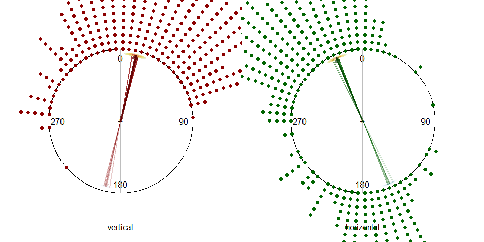

```r
par(pty = 's')
par(mfrow = c(1, length(conds)), mar = c(0,0,0,0))
for(cnd in conds)
{
  PCfun(angles = subset(hd, condition %in% cnd)$angle_deg, col = cond_cols[[cnd]],
        shrink = 1.5, plot_rho = FALSE, title = cnd)
  for(i in id_tab$Individual[id_cond[, cnd]])
  {
    ModeArrows(mu_id[i + 1, cnd], kappa_id[i + 1, cnd], w1_id[i + 1, cnd],
               col = cond_cols[[cnd]], lwd = 2)
  }
  pd = pop_draws[[cnd]]
  ModeContours(pd$mu, pd$kappa, pd$w1)
  ModeArrows(MedCDraws(pd$mu), median(pd$kappa), median(pd$w1),
             col = adjustcolor(cond_cols[[cnd]], offset = c(rep(-0.2, 3), 0)),
             lwd = 5, length = 0.1/1.25)
}
```

```r
for(cnd in conds)
{
  print(paste(cnd, 'forward direction (mu1), degrees:', paste(QDegDraws(pop_draws[[cnd]]$mu), collapse = ', ')))
}
```

```
## [1] "vertical forward direction (mu1), degrees: 13, 5, 21"
## [1] "horizontal forward direction (mu1), degrees: -23, -30, -15"
```

## Dance-level state assignments

Each dance’s posterior state probabilities against its unimodal ($R_1$) and axial ($R_2$) mean resultant lengths. Colours mix the state colours in proportion to the posterior probability of each state, and point size scales with the number of waggle runs.

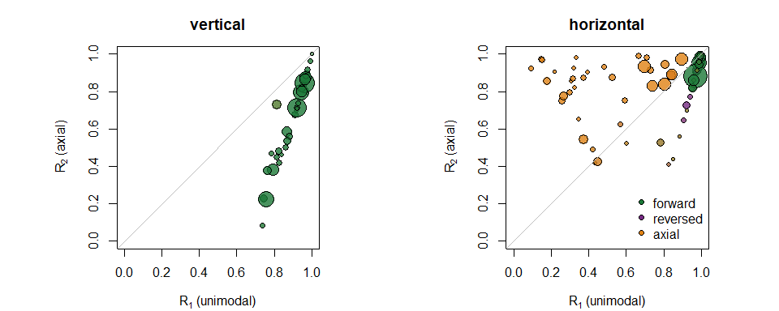

```r
dance_stats = do.call(rbind,
                      lapply(split(hd$angle, hd$Dance),
                             function(a)
                             {
                               data.frame(R1 = Mod(mean(exp(1i * a))),
                                          R2 = Mod(mean(exp(2i * a))),
                                          n_runs = length(a))
                             }))
dance_tab = cbind(dance_tab, dance_stats[as.character(dance_tab$Dance), ])
par(mfrow = c(1, length(conds)), mar = c(4, 4, 3, 1), pty = 's')
for(cnd in conds)
{
  sel = dance_tab$condition == cnd
  rgb_mix = ps_d[sel, , drop = FALSE] %*% t(col2rgb(unlist(state_cols[model_states]))) / 255
  plot(dance_tab$R1[sel], dance_tab$R2[sel], xlim = c(0, 1), ylim = c(0, 1),
       pch = 21, bg = rgb(rgb_mix[, 1], rgb_mix[, 2], rgb_mix[, 3], alpha = 0.8),
       cex = 0.6 + 0.08 * dance_tab$n_runs[sel],
       xlab = expression(R[1] ~ '(unimodal)'), ylab = expression(R[2] ~ '(axial)'), main = cnd)
  abline(a = 0, b = 1, col = 'gray')
}
legend('bottomright', legend = model_states, pt.bg = unlist(state_cols[model_states]), pch = 21, bty = 'n')
```

## Concentration

Posterior concentration ($\kappa$) of waggle runs around each mode, for a typical dance in each condition.

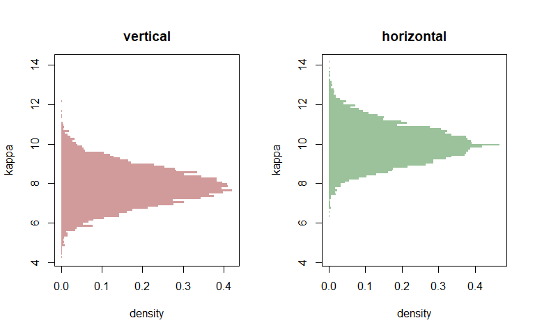

```r
par(mfrow = c(1, length(conds)))
kappa_lim = range(unlist(lapply(pop_draws, `[[`, 'kappa')))
for(cnd in conds)
{
  VertHist(data = pop_draws[[cnd]]$kappa,
           main = paste0('\n', cnd),
           ylab = 'kappa',
           ylim = kappa_lim,
           col = adjustcolor(cond_cols[[cnd]], alpha.f = 100/255),
           cex.axis = 0.7)
}
```

```r
print(pred_table[, c('condition', 'kappa_median', 'kappa_lower', 'kappa_upper', 'rho_median')])
```

```
##    condition kappa_median kappa_lower kappa_upper rho_median
## 1   vertical         7.86        5.94        9.85      0.934
## 2 horizontal         9.96        8.17       11.99      0.948
```

## Variation across individuals and dances

Standard deviations of individual and dance offsets in direction (in degrees; for von Mises individual offsets, the circular SD, $\sqrt{-2 \log A_1(\kappa_u)}$), and of individual and dance effects on $\kappa$ and on the state logits.

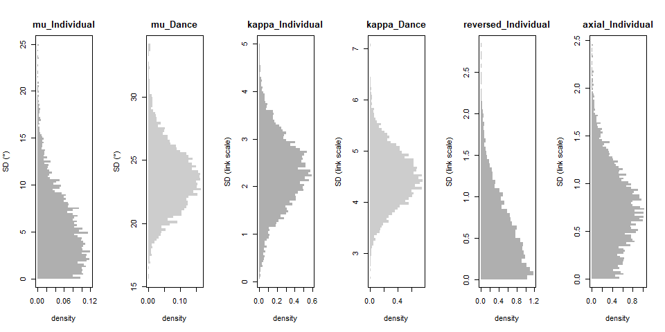

```r
sigma_params = grep('_sigma$', names(draws_final), value = TRUE)
par(mfrow = c(1, length(sigma_params)))
for(sp in sigma_params)
{
  is_mu = grepl('^mu_', sp)
  VertHist(data = if(is_mu){deg(draws_final[[sp]])}else{draws_final[[sp]]},
           main = paste0('\n', gsub('_sigma', '', sp)),
           ylab = if(is_mu){'SD (°)'}else{'SD (link scale)'},
           col = adjustcolor(if(grepl('Dance', sp)){'gray50'}else{'gray20'}, alpha.f = 100/255),
           cex.axis = 0.7)
}
```

```r
sigma_table = do.call(rbind,
                      lapply(sigma_params,
                             function(sp)
                             {
                               is_mu = grepl('^mu_', sp)
                               q = if(is_mu){QDraws(deg(draws_final[[sp]]), digits = 1)}else{QDraws(draws_final[[sp]])}
                               data.frame(parameter = sp, units = if(is_mu){'degrees'}else{'link scale'},
                                          median = q[1], lower = q[2], upper = q[3], row.names = NULL)
                             }))
print(sigma_table)
```

```
##                   parameter      units median lower upper
## 1       mu_Individual_sigma    degrees   4.90  0.30 14.60
## 2            mu_Dance_sigma    degrees  23.40 18.90 28.90
## 3    kappa_Individual_sigma link scale   2.29  0.74  3.75
## 4         kappa_Dance_sigma link scale   4.48  3.43  5.58
## 5 reversed_Individual_sigma link scale   0.50  0.02  1.70
## 6    axial_Individual_sigma link scale   0.71  0.05  1.63
```

# Model comparison

Leave-one-dance-out cross-validation (PSIS-LOO) for the models fitted in `HS_circGLMM_states.ipynb` with the same direction prior. Each dance has its own direction, concentration and state, so leaving one out changes the posterior substantially and PSIS is often unreliable (many dances with Pareto $\hat{k} > 0.7$): treat this as provisional, pending K-fold cross-validation.

```r
model_labels = c(two_states = 'Forward/reversed, condition-dependent',
                 three_states_same = 'Forward/reversed/axial, same in all conditions',
                 three_states_condition = 'Forward/reversed/axial, condition-dependent')
model_files = file.path(params$model_dir,
                        paste0('HS_states_', params$elevation, '_', params$direction_prior, '_',
                               names(model_labels), '.nc'))
names(model_files) = model_labels
model_files = model_files[file.exists(model_files)]
az_py = reticulate::import("arviz", convert = FALSE)
loo_list = lapply(model_files, function(f){az_py$loo(az_py$from_netcdf(f))})
comparison = reticulate::py_to_r(az_py$compare(reticulate::dict(loo_list), ic = 'loo'))
print(comparison[, c('rank', 'elpd_loo', 'p_loo', 'elpd_diff', 'weight', 'se', 'dse', 'warning')],
      digits = 3)
```

```
##                                                rank elpd_loo p_loo elpd_diff
## Forward/reversed/axial, condition-dependent       0     -672   144         0
## Forward/reversed/axial, same in all conditions    1     -692   147        20
## Forward/reversed, condition-dependent             2     -814   129       141
##                                                  weight   se   dse warning
## Forward/reversed/axial, condition-dependent    9.56e-01 61.1  0.00    TRUE
## Forward/reversed/axial, same in all conditions 6.33e-12 62.2  4.13    TRUE
## Forward/reversed, condition-dependent          4.37e-02 70.1 32.55    TRUE
```

```r
for(nm in names(loo_list))
{
  k = reticulate::py_to_r(loo_list[[nm]]$pareto_k$values)
  print(paste0(nm, ': ', sum(k > 0.7), ' of ', length(k), ' dances with Pareto k > 0.7'))
}
```

```
## [1] "Forward/reversed, condition-dependent: 86 of 99 dances with Pareto k > 0.7"
## [1] "Forward/reversed/axial, same in all conditions: 84 of 99 dances with Pareto k > 0.7"
## [1] "Forward/reversed/axial, condition-dependent: 82 of 99 dances with Pareto k > 0.7"
```

# Appendix

## Individual direction offsets

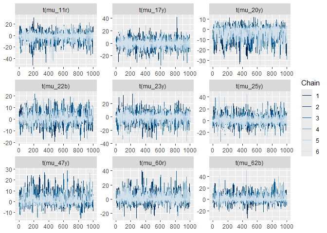

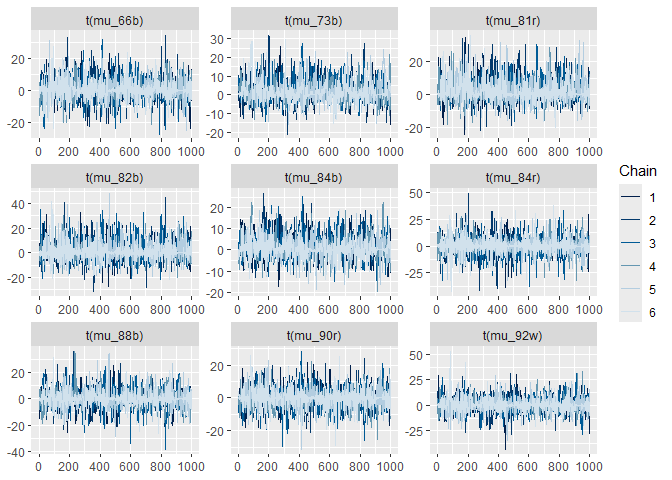

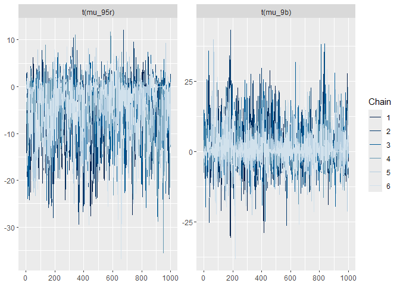

```r
ind_df = posterior::as_draws_df(
  data.frame(.chain = rep(1:n_chains, each = n_draws),
             .iteration = rep(1:n_draws, times = n_chains),
             setNames(as.data.frame(mu_ind), paste0('mu_', id_tab$Individual_label)),
             check.names = FALSE))
plt_panels = 9
for(id in 0:(ceiling(n_ind/plt_panels) - 1))
{
  idx = (id * plt_panels + 1):min((id + 1) * plt_panels, n_ind)
  print(mcmc_trace(ind_df, pars = paste0('mu_', id_tab$Individual_label[idx]),
                   facet_args = list(ncol = 3, nrow = 3),
                   transformations = function(x){deg(x)}))
}
```